# IODS course final assignment

Tuukka Kangas tuukka.kangas@helsinki.fi

March 5th, 2017

```r
#Needed libraries
library(GGally, warn.conflicts = FALSE)
library(ggplot2, warn.conflicts = FALSE)
library(corrplot, warn.conflicts = FALSE)
library(tidyr, warn.conflicts = FALSE)
library(dplyr, warn.conflicts = FALSE)
library(cluster, warn.conflicts = FALSE)
library(fpc, warn.conflicts = FALSE)
```

# 1 Abstract

# 2 Aim

My aim is to visualize differences in trust and quality of local governances in different european cities. My goal is to find what are the most influental variables to explain differences between cities in quality and trust of local governances.

As a hypothesis, I think I will find clusters of cities. Because all cities are european, I think the cities are going to separate to the rich and poor countries. Another hypothesis is that northern european cities will be one group and southern european cities another one. As a result I hope that I have a plot that will clearly show us clusters of cities.

# 3 Data

Because dataset has some problems (especially missing values), too much variables and I would like have more background variables, there is done some data wrangling. The wrangling part is done in seperate script that can be found [here](https://github.com/tvkangas/IODS-final/blob/master/wrangling.R). In the script is explained what is done.

After the wrangling, the dataset contains 17 variables. There are 12 variables from the surveys, but now most of them contains information from multiple original variables. Those 12 varibles contains information from trust and quality of local governance. There is also two variables describing population of the city: population share comparing to the country and the populations. Then there is id-variables and one factorial variable that tells if the city is a capital. Variables are described thoroughly in separate file that can be found [here](https://github.com/tvkangas/IODS-final/blob/master/dataInformation.txt). In that text file is also source for the populations.

```r
#Reading the dataset. The dataset is read from my GitHub-page.
#After reading citynames are used as rownames so after that running number and citynames can be removed from the dataset

trust_dataTMP <- read.csv("https://raw.githubusercontent.com/tvkangas/IODS-final/master/trustdata.csv", sep=",", dec=".", header = TRUE)
rownames(trust_dataTMP) <- trust_dataTMP$city
trust_dataTMP <- dplyr::select(trust_dataTMP, -X)
trust_dataTMP <- dplyr::select(trust_dataTMP, -city)

#After bringing the dataset, there are some summaries about the data.
#First column in the dataset can't be used because it is factorial variable containing the country
str(trust_dataTMP)
```

```
## 'data.frame':    69 obs. of  16 variables:
##  $ country   : Factor w/ 21 levels "Austria","Belgium",..: 6 14 2 11 19 10 21 16 5 2 ...
##  $ capital   : int  0 1 0 1 0 1 0 0 0 1 ...
##  $ faircourt : num  0.61 0.76 0.42 0.5 0.32 0.52 0.51 0.43 0.49 0.41 ...
##  $ safe      : num  0.89 0.83 0.66 0.44 0.68 0.65 0.72 0.79 0.68 0.45 ...
##  $ break.    : num  0.14 0.13 0.15 0.17 0.12 0.12 0.13 0.17 0.15 0.22 ...
##  $ workdis   : num  0.11 0.21 0.18 0.28 0.32 0.23 0.18 0.29 0.25 0.29 ...
##  $ trust     : num  0.783 0.583 0.513 0.477 0.483 ...
##  $ corruption: num  0.925 0.868 0.83 0.675 0.725 ...
##  $ freedom   : num  0.876 0.901 0.794 0.669 0.698 ...
##  $ bribe     : num  0.07 0.042 0.064 0.39 0.038 0.074 0.054 0.202 0.072 0.19 ...
##  $ houdem    : num  0.775 0.905 0.795 0.82 0.89 0.815 0.69 0.78 0.805 0.76 ...
##  $ busfine   : num  0.83 0.775 0.74 0.91 0.815 0.79 0.805 0.835 0.86 0.74 ...
##  $ govopen   : num  0.565 0.465 0.445 0.2 0.455 0.385 0.52 0.525 0.255 0.335 ...
##  $ lawful    : num  0.833 0.825 0.828 0.677 0.752 ...
##  $ citypop   : num  327 849 511 664 1609 ...
##  $ share     : num  0.0599 0.0515 0.0492 0.0621 0.0398 ...
```

```r
summary(trust_dataTMP)
```

```
##      country      capital         faircourt           safe
##  Belgium : 4   Min.   :0.0000   Min.   :0.2800   Min.   :0.210
##  Finland : 4   1st Qu.:0.0000   1st Qu.:0.4100   1st Qu.:0.610
##  Greece  : 4   Median :0.0000   Median :0.4700   Median :0.700
##  Hungary : 4   Mean   :0.2899   Mean   :0.4797   Mean   :0.677
##  Portugal: 4   3rd Qu.:1.0000   3rd Qu.:0.5500   3rd Qu.:0.770
##  Romania : 4   Max.   :1.0000   Max.   :0.7600   Max.   :0.940
##  (Other) :45
##      break.         workdis           trust          corruption
##  Min.   :0.000   Min.   :0.0100   Min.   :0.2433   Min.   :0.3025
##  1st Qu.:0.080   1st Qu.:0.1500   1st Qu.:0.4833   1st Qu.:0.6350
##  Median :0.120   Median :0.2000   Median :0.5533   Median :0.7350
##  Mean   :0.112   Mean   :0.1988   Mean   :0.5574   Mean   :0.7138
##  3rd Qu.:0.140   3rd Qu.:0.2500   3rd Qu.:0.6500   3rd Qu.:0.8275
##  Max.   :0.220   Max.   :0.4000   Max.   :0.8233   Max.   :0.9500
##
##     freedom           bribe            houdem          busfine
##  Min.   :0.5083   Min.   :0.0140   Min.   :0.3900   Min.   :0.6950
##  1st Qu.:0.6767   1st Qu.:0.0560   1st Qu.:0.7000   1st Qu.:0.7650
##  Median :0.7600   Median :0.0800   Median :0.7750   Median :0.8150
##  Mean   :0.7551   Mean   :0.1519   Mean   :0.7586   Mean   :0.8229
##  3rd Qu.:0.8383   3rd Qu.:0.2840   3rd Qu.:0.8200   3rd Qu.:0.8800
##  Max.   :0.9025   Max.   :0.4660   Max.   :0.9400   Max.   :0.9850
##
##     govopen           lawful          citypop            share
##  Min.   :0.1100   Min.   :0.5250   Min.   :  37.54   Min.   :0.00807
##  1st Qu.:0.3000   1st Qu.:0.6775   1st Qu.: 270.42   1st Qu.:0.02034
##  Median :0.3850   Median :0.7725   Median : 491.27   Median :0.03686
##  Mean   :0.3846   Mean   :0.7446   Mean   : 867.88   Mean   :0.05623
##  3rd Qu.:0.4600   3rd Qu.:0.8225   3rd Qu.: 972.64   3rd Qu.:0.05993
##  Max.   :0.6750   Max.   :0.8625   Max.   :8673.71   Max.   :0.33533
##
```

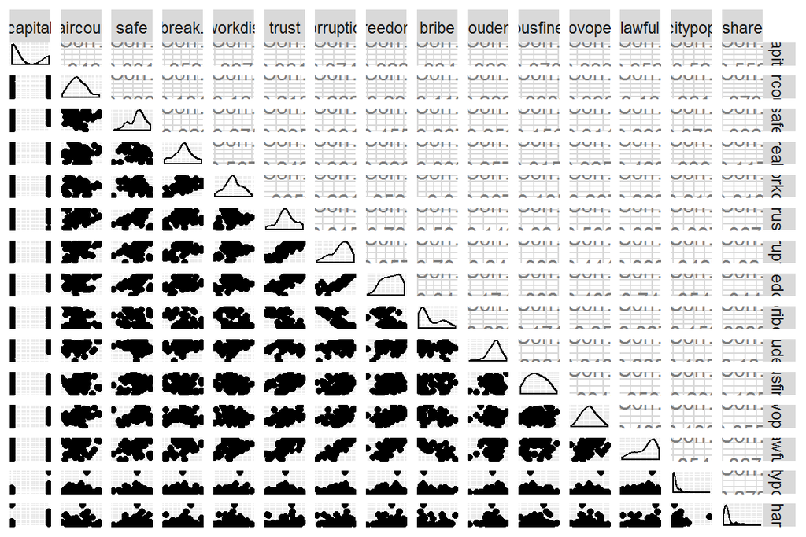

```r
ggpairs(data = trust_dataTMP, columns = 2:ncol(trust_dataTMP), axisLabels = "none")
```

```r
trust_dataTMPcor <- dplyr::select(trust_dataTMP, -country)
cor_matrix<-cor(trust_dataTMPcor)
cor_matrix %>% round(digits = 2)
```

```
##            capital faircourt  safe break. workdis trust corruption freedom
## capital       1.00      0.05 -0.03   0.06    0.10 -0.06      -0.07   -0.02
## faircourt     0.05      1.00 -0.03   0.10   -0.16  0.22       0.26    0.29
## safe         -0.03     -0.03  1.00  -0.32   -0.27  0.34       0.30    0.46
## break.        0.06      0.10 -0.32   1.00    0.57  0.25       0.36    0.23
## workdis       0.10     -0.16 -0.27   0.57    1.00  0.07       0.22    0.05
## trust        -0.06      0.22  0.34   0.25    0.07  1.00       0.82    0.72
## corruption   -0.07      0.26  0.30   0.36    0.22  0.82       1.00    0.86
## freedom      -0.02      0.29  0.46   0.23    0.05  0.72       0.86    1.00
## bribe         0.03     -0.11 -0.27  -0.33   -0.30 -0.59      -0.79   -0.64
## houdem        0.07      0.21 -0.26   0.26    0.37 -0.14       0.24    0.17
## busfine      -0.08      0.10  0.16  -0.02   -0.19  0.33       0.08    0.08
## govopen      -0.03      0.40  0.31  -0.03   -0.21  0.51       0.44    0.49
## lawful       -0.05      0.16  0.30   0.43    0.29  0.69       0.89    0.74
## citypop       0.52      0.06 -0.08   0.03    0.22 -0.10       0.04    0.05
## share         0.55      0.07  0.08   0.12   -0.02  0.07      -0.02    0.04
##            bribe houdem busfine govopen lawful citypop share
## capital     0.03   0.07   -0.08   -0.03  -0.05    0.52  0.55
## faircourt  -0.11   0.21    0.10    0.40   0.16    0.06  0.07
## safe       -0.27  -0.26    0.16    0.31   0.30   -0.08  0.08
## break.     -0.33   0.26   -0.02   -0.03   0.43    0.03  0.12
## workdis    -0.30   0.37   -0.19   -0.21   0.29    0.22 -0.02
## trust      -0.59  -0.14    0.33    0.51   0.69   -0.10  0.07
## corruption -0.79   0.24    0.08    0.44   0.89    0.04 -0.02
## freedom    -0.64   0.17    0.08    0.49   0.74    0.05  0.04
## bribe       1.00  -0.21    0.17   -0.35  -0.83   -0.15  0.00
## houdem     -0.21   1.00    0.01   -0.05   0.24    0.20 -0.13
## busfine     0.17   0.01    1.00    0.08   0.05   -0.20  0.12
## govopen    -0.35  -0.05    0.08    1.00   0.40    0.14 -0.06
## lawful     -0.83   0.24    0.05    0.40   1.00    0.05  0.07
## citypop    -0.15   0.20   -0.20    0.14   0.05    1.00  0.27
## share       0.00  -0.13    0.12   -0.06   0.07    0.27  1.00
```

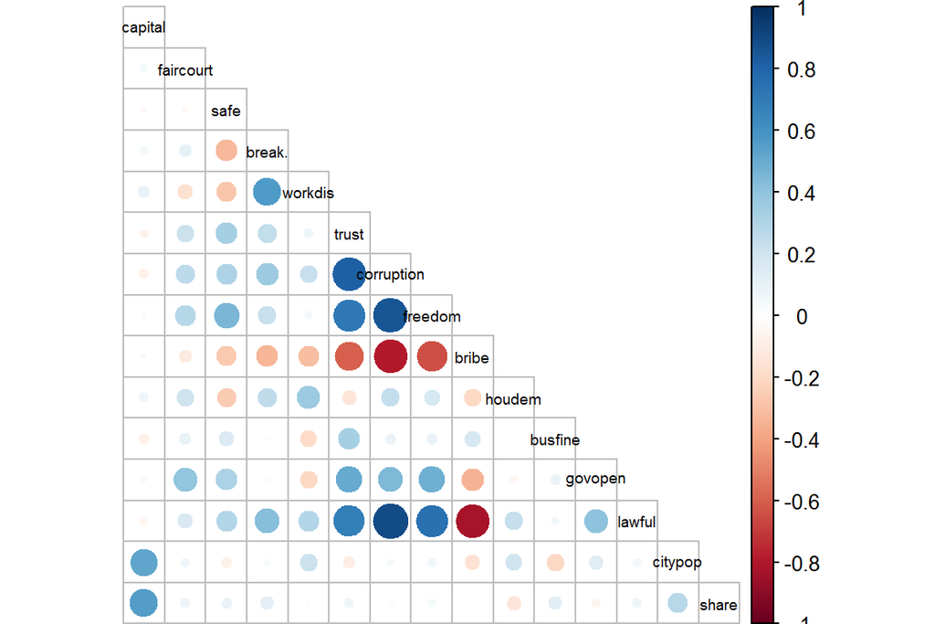

```r
corrplot(cor_matrix, method="circle", type="lower", cl.pos = "r", tl.pos = "d", tl.cex = 0.6, tl.col="black")
```

With the correlation plot can be seen that there are some correlations between the variables. Capitals seems to be larger cities. Then there is bigger correlations between *corruption*, *trust*, *freedom*, *bribe* and *lawful.* Then there is some variables that have very low correlations with other variables like *busfine*, *faircourt*, *houdem* and *capital*.

For the further analysis, the dataset need to be standardized. That scales all variables so that their means are zero.

```r
#The column country has to be ignored in the scaling.
#Column is added later back
trust_data<- scale(trust_dataTMP[, -c(1)])
countries <- dplyr::select(trust_dataTMP, country)
trust_data <- cbind(trust_data, countries)
```

# 4 Methods

My main idea is to find clusters within cities are somewhat similar. For that purpose k-means clustering will be my main method, but I will utilize other methods to create better visualization for the data.

## 4.1 k-means

k-means clustering is an old method to cluster data. Its purpose is to do partition for the data to *k* clusters. Every observation needs to belong to some cluster. The idea is to do partition so that within-cluster sum of squares is minimized. The minimization is done iteratively until the centroids are not anymore changed. There are some problems with k-means clustering, but some problems are already solved (scaling). One problem is how many cluster should be used. I have relatively small dataset so I think the number would be quite low.

## 4.2 ANOVA

Analysis of variance (ANOVA) is a method that is used to analyze differences between groups. The main idea is to analyze if the means of the groups differ. ANOVA can be used for multiple groups so it’s more versatile than t-test. The assumptions for ANOVA can be read from [Wikipedia](https://en.wikipedia.org/wiki/Analysis_of_variance#Assumptions_of_ANOVA), but main points are that observations need to be independent, residuals should be normally distributed and homoscedasticity (variances of the groups should be same). Other requirement is that mean can be calculated. I will do ANOVA with one depedent varible. The idea of ANOVA is that variance is separated two parts: between and within treatments. Then F-test is used to see if the difference is significant enough. Null hypothesis is always that there is no differences between groups. p-value of 0.05 is used as a limit.

# 5 k-means

First step is to determine correct number of clusters. For the determination, the distances between the observations need to be calculated. Distances are calculated with three different methods.

```r
#Different methods for distance measurements
#Column country needs to be removed for distance measurements because it's not numeric
#City population needs to be removed because there is few outliers that effects too much to data
#Capital is another variable that effects too much for clustering, so I will remove it also

dist_data <- dplyr::select(trust_dataTMP, -country)
dist_data <- dplyr::select(dist_data, -citypop)
dist_data <- dplyr::select(dist_data, -capital)
dist_eu <- dist(dist_data, method = "euclidean") #euclidean
dist_man <- dist(dist_data, method = "manhattan") #manhattan
dist_min <- dist(dist_data, method = "minkowski") #minkowski
summary(dist_eu)
```

```
##    Min. 1st Qu.  Median    Mean 3rd Qu.    Max.
## 0.08897 0.37590 0.51310 0.52500 0.66140 1.16500
```

```r
summary(dist_man)
```

```
##    Min. 1st Qu.  Median    Mean 3rd Qu.    Max.
##  0.2405  1.0580  1.4580  1.5130  1.9290  3.2790
```

```r
summary(dist_min)
```

```
##    Min. 1st Qu.  Median    Mean 3rd Qu.    Max.
## 0.08897 0.37590 0.51310 0.52500 0.66140 1.16500
```

It seems that all three distance measurement methods gives a little different results. Euclidean ja minkowski methods are giving quite same results, but manhattan method gives a bit larger values. I will continue with euclidean and manhattan methods.

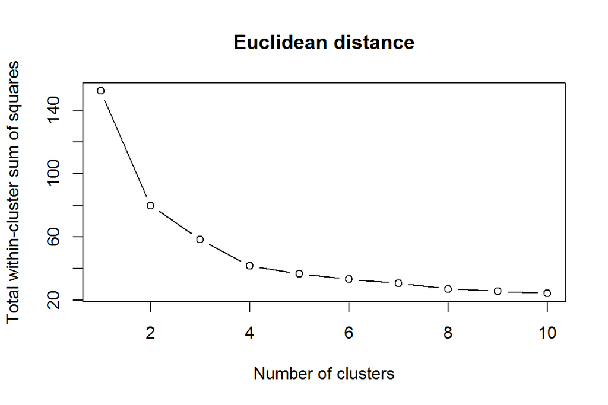

```r
#Next chunk of code gives a graph from where suitable number of cluster can be determined.
set.seed(12)
k_max <- 10

twcss_eu <- sapply(1:k_max, function(k){kmeans(dist_eu, k)$tot.withinss})
plot(1:k_max, twcss_eu, type='b', xlab="Number of clusters", ylab="Total within-cluster sum of squares", main = "Euclidean distance")
```

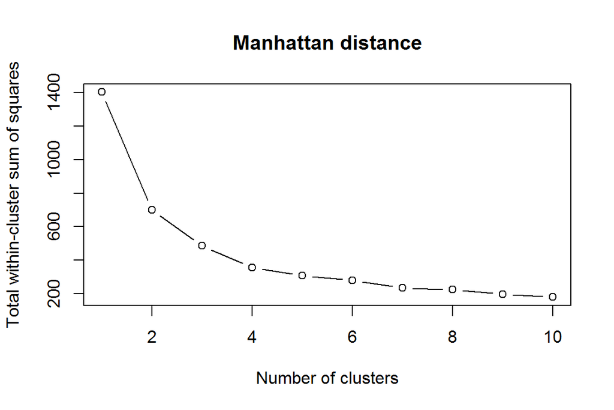

```r
twcss_man <- sapply(1:k_max, function(k){kmeans(dist_man, k)$tot.withinss})
plot(1:k_max, twcss_man, type='b', xlab="Number of clusters", ylab="Total within-cluster sum of squares", main = "Manhattan distance")
```

The correct (or at least good guess) number of clusters can be read from the graph. In both graphs the absolute value of the slope has highest value between points 1-2 so 2 is a good point to start. With manhattan distance it is worth of trying also k=3.

```r
km_eu_2 <-kmeans(dist_eu, centers = 2)
km_man_2 <-kmeans(dist_man, centers = 2)
km_man_3 <- kmeans(dist_man, centers = 3)

#For saving some space I will display now only the most important value "within cluster sum of squares by cluster"

print(paste0("Euclidian, 2 centroids: ", round(km_eu_2$betweenss / km_eu_2$totss, 3)))
```

```
## [1] "Euclidian, 2 centroids: 0.477"
```

```r
print(paste0("Manhattan, 2 centroids: ", round(km_man_2$betweenss / km_man_2$totss,3 )))
```

```
## [1] "Manhattan, 2 centroids: 0.5"
```

```r
print(paste0("Manhattan, 3 centroids: ", round(km_man_3$betweenss / km_man_3$totss, 3)))
```

```
## [1] "Manhattan, 3 centroids: 0.654"
```

A good indicator to the “goodness of k-means” is *Within cluster sum of squares by cluster* that can be read from tables. That can be consider as a value that tells how much variance in the dataset can be explained with clustering. k-means with euclidean method (two centroids) is explaining 48 % of variance. With manhattan method (two and three centroids) values are 50 % and 65 % respectively. Adding centroids would increase that number, but it’s not good idea because my dataset is quite small. Because of that, I will continue with k-means with manhattan distance measurement method with three centroids.

```r
km_man_3
```

```
## K-means clustering with 3 clusters of sizes 24, 16, 29
##
## Cluster means:
##      Aarhus Amsterdam   Antwerp   Athens Barcelona    Berlin Birmingham
## 1 1.8291266 1.6005136 0.9875477 1.169841 0.9308031 0.8801774   1.181934
## 2 2.5887468 2.5091991 1.9269704 1.471404 1.8733969 1.8476052   2.029066
## 3 0.9440712 0.9822794 0.9180287 2.075316 1.3350715 0.8956854   0.779643
##       Braga      Brno Brusssels Bucharest Budapest    Celje Charleroi
## 1 0.9788469 0.7794491 0.9294281  1.261582 1.414780 1.983404 0.9532148
## 2 1.8648469 1.7211880 1.7860926  1.129534 1.741799 1.355981 1.8542202
## 3 1.1412797 1.1447191 1.5886913  1.855008 1.372926 2.541921 1.2884302
##   Cluj-Napoca Copenhagen   Cracow Debrecen    Espoo     Ghent   Glasgow
## 1    1.024295  1.8122905 1.976757 1.669727 1.864215 1.1117207 1.2656110
## 2    1.158918  2.6292164 1.262314 2.230758 2.561448 1.9831943 2.0226541
## 3    1.557244  0.9260623 2.403765 1.276674 1.126749 0.8556059 0.8890728
##    Goteborg      Graz   Hamburg  Helsinki     Iasi      Linz   Lisbon
## 1 1.3661821 1.5128356 0.9919450 1.5533968 1.498670 1.4412486 0.824122
## 2 2.1461947 2.2211582 1.9720055 2.3699337 1.317338 2.2266736 1.815510
## 3 0.8014304 0.8243627 0.7983532 0.9475853 2.246853 0.8555342 1.157238
##   Ljubljana     Lodz    London      Lyon    Madrid     Malmo  Maribor
## 1  1.594052 2.053460 1.2178545 0.9985868 0.9030219 1.2280029 1.668602
## 2  1.299571 1.482544 2.1214304 1.9812549 1.8491854 2.1466364 1.228282
## 3  1.973907 2.528990 0.9608453 0.9124195 1.2955440 0.8419003 2.036954
##   Marseille     Milan  Miskolc    Munich   Naples    Narva    Odense
## 1 0.9515277 0.8895068 1.683635 1.1207482 1.215050 1.224861 1.8871648
## 2 1.8100916 1.6587031 2.419798 1.9852555 1.527002 1.838022 2.6277894
## 3 1.6048602 1.7379861 1.180111 0.8196356 2.124519 1.979954 0.9562884
##     Ostrava     Paris   Patras  Plovdiv     Porto    Prague   Rijeka
## 1 0.8011194 0.9031268 1.100038 1.574523 0.8086311 0.8250148 2.047766
## 2 1.7480279 1.8067839 1.625984 1.244256 1.6941063 1.8251784 1.235023
## 3 1.5223724 0.9537686 1.736703 2.062821 1.1786677 1.3881005 2.494392
##        Rome Rotterdam Salonica    Sofia    Split Stockholm   Szeged
## 1 0.9938315  1.443092 1.135049 2.038340 2.064601 1.3932505 1.508434
## 2 1.6598916  2.414887 1.546214 1.463275 1.247064 2.2585927 1.352998
## 3 1.9446925  0.961981 1.625970 2.813944 2.497668 0.7870924 1.943057
##    Tallinn  Tampere     Tartu The Hague Thessaloniki Timisoara    Turku
## 1 1.314518 1.598277 1.4431246 1.5518710    0.9455765  1.082881 1.478532
## 2 2.207544 2.375772 2.3071687 2.5135009    1.4802760  1.176593 2.282238
## 3 1.168901 1.015408 0.7860129 0.9811813    1.6481197  1.819483 1.007508
##    Valencia    Varna   Warsaw    Vienna Vila Nova de Gaia   Zagreb
```

[output cut: 36 more lines]

```
##                 1                 1                 3                 1
##             Varna            Warsaw            Vienna Vila Nova de Gaia
##                 3                 2                 3                 1
##            Zagreb
##                 2
##
## Within cluster sum of squares by cluster:
## [1] 156.6360 155.4965 173.5799
##  (between_SS / total_SS =  65.4 %)
##
## Available components:
##
## [1] "cluster"      "centers"      "totss"        "withinss"
## [5] "tot.withinss" "betweenss"    "size"         "iter"
## [9] "ifault"
```

```r
dist_data$cluster=factor(km_man_3$cluster)
centers=as.data.frame(km_man_3$centers)
trust_data$cluster<- km_man_3$cluster
```

## 5.1 Summary and notes, k-means

Now I have performed k-means clustering. For me results are very interesting and it seems that clustering was successful. Now I am interested how to move on: I want to see what are the common factors in the groups, what are the most influental variables and what variables would predict clustering (if new city is brought to the data).

Clustering was done iteratively. Some variables needed to remove ( *capital* and *citypop*) because their influence was too big. With *capital* clusters were “capitals” and “no-capitals”. Without them clustering was more rewarding.

## 5.2 Variables in clustering

The next step is to see how different clusters differs from each other. In the other words, I would like to find most influental variables that make differences in k-means. According Burns and Burns (Business Research Methods and Statistics Using SPSS) one possible method is to do ANOVA. ANOVA is explained better in Methods-part. It’s reasonable to assume that observations are independent. Homoscedasticities and normality of errors will be observed.

```r
summary(aov(faircourt ~ cluster, data=trust_data))
```

```
##             Df Sum Sq Mean Sq F value  Pr(>F)
## cluster      1   8.49   8.494   9.564 0.00289 **
## Residuals   67  59.51   0.888
## ---
## Signif. codes:  0 '***' 0.001 '**' 0.01 '*' 0.05 '.' 0.1 ' ' 1
```

```r
summary(aov(safe ~ cluster, data=trust_data))
```

```
##             Df Sum Sq Mean Sq F value   Pr(>F)
## cluster      1  14.56  14.563   18.26 6.24e-05 ***
## Residuals   67  53.44   0.798
## ---
## Signif. codes:  0 '***' 0.001 '**' 0.01 '*' 0.05 '.' 0.1 ' ' 1
```

```r
summary(aov(workdis ~ cluster, data=trust_data))
```

```
##             Df Sum Sq Mean Sq F value   Pr(>F)
## cluster      1  12.87  12.872   15.64 0.000187 ***
## Residuals   67  55.13   0.823
## ---
## Signif. codes:  0 '***' 0.001 '**' 0.01 '*' 0.05 '.' 0.1 ' ' 1
```

```r
summary(aov(trust ~ cluster, data=trust_data))
```

```
##             Df Sum Sq Mean Sq F value   Pr(>F)
## cluster      1  15.12  15.123   19.16 4.31e-05 ***
## Residuals   67  52.88   0.789
## ---
## Signif. codes:  0 '***' 0.001 '**' 0.01 '*' 0.05 '.' 0.1 ' ' 1
```

```r
summary(aov(corruption ~ cluster, data=trust_data))
```

```
##             Df Sum Sq Mean Sq F value   Pr(>F)
## cluster      1  13.46  13.460   16.54 0.000128 ***
## Residuals   67  54.54   0.814
## ---
## Signif. codes:  0 '***' 0.001 '**' 0.01 '*' 0.05 '.' 0.1 ' ' 1
```

```r
summary(aov(freedom ~ cluster, data=trust_data))
```

```
##             Df Sum Sq Mean Sq F value   Pr(>F)
## cluster      1  24.26  24.258   37.16 6.05e-08 ***
## Residuals   67  43.74   0.653
## ---
## Signif. codes:  0 '***' 0.001 '**' 0.01 '*' 0.05 '.' 0.1 ' ' 1
```

```r
summary(aov(bribe ~ cluster, data=trust_data))
```

```
##             Df Sum Sq Mean Sq F value Pr(>F)
## cluster      1    6.3   6.302   6.844  0.011 *
## Residuals   67   61.7   0.921
## ---
## Signif. codes:  0 '***' 0.001 '**' 0.01 '*' 0.05 '.' 0.1 ' ' 1
```

```r
summary(aov(houdem ~ cluster, data=trust_data))
```

```
##             Df Sum Sq Mean Sq F value Pr(>F)
## cluster      1   3.24   3.243   3.356 0.0714 .
## Residuals   67  64.76   0.967
## ---
## Signif. codes:  0 '***' 0.001 '**' 0.01 '*' 0.05 '.' 0.1 ' ' 1
```

```r
summary(aov(busfine ~ cluster, data=trust_data))
```

```
##             Df Sum Sq Mean Sq F value Pr(>F)
## cluster      1   0.35  0.3498   0.346  0.558
## Residuals   67  67.65  1.0097
```

```r
summary(aov(govopen ~ cluster, data=trust_data))
```

```
##             Df Sum Sq Mean Sq F value   Pr(>F)
## cluster      1  16.44   16.44   21.36 1.79e-05 ***
## Residuals   67  51.56    0.77
## ---
## Signif. codes:  0 '***' 0.001 '**' 0.01 '*' 0.05 '.' 0.1 ' ' 1
```

```r
summary(aov(lawful ~ cluster, data=trust_data))
```

```
##             Df Sum Sq Mean Sq F value  Pr(>F)
## cluster      1   8.68   8.680   9.803 0.00258 **
## Residuals   67  59.32   0.885
## ---
## Signif. codes:  0 '***' 0.001 '**' 0.01 '*' 0.05 '.' 0.1 ' ' 1
```

It seems that with all other variables than *houdem* and *busfine* there is statistically significant differences between cluster groups (p-value less than 0,05). The two biggest F-values are with *freedom* and *govopen*. I take those two for better observations are see if required assumptions are fulfilled.

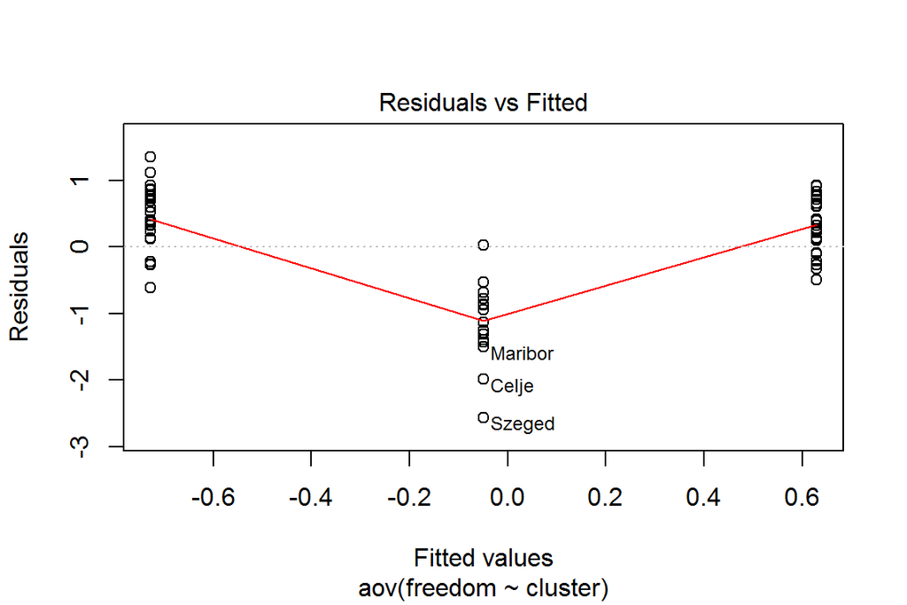

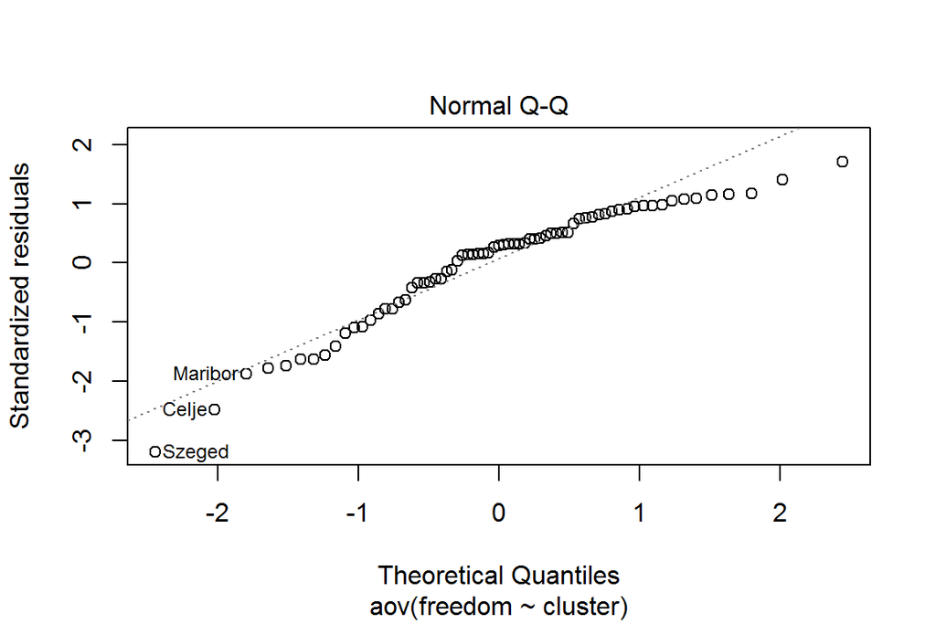

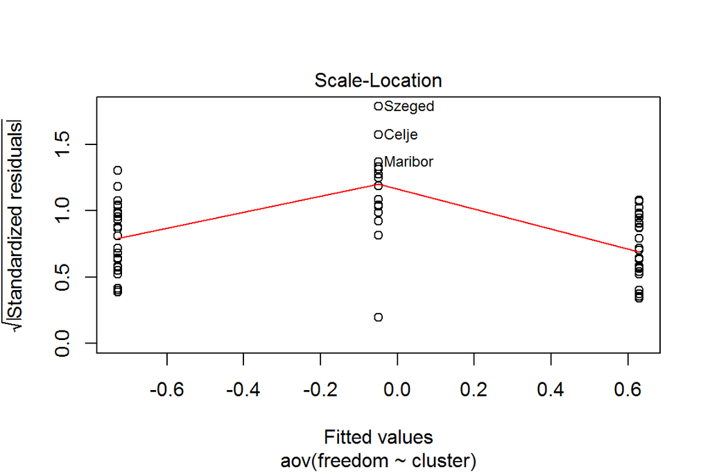

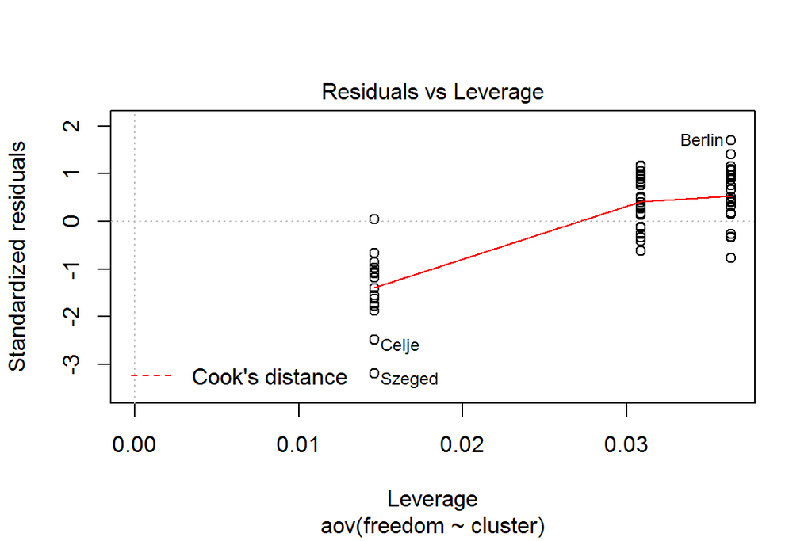

```r
fitfreedom <- aov(freedom ~ cluster, data=trust_data)
fitgovopen <- aov(govopen ~ cluster, data=trust_data)
plot(fitfreedom)
```

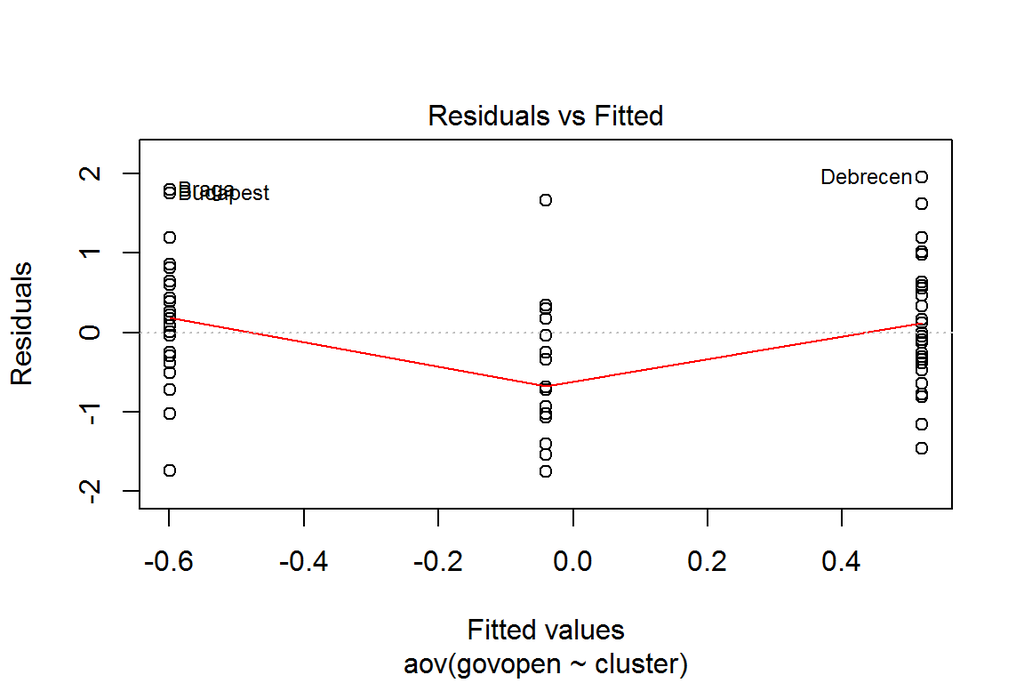

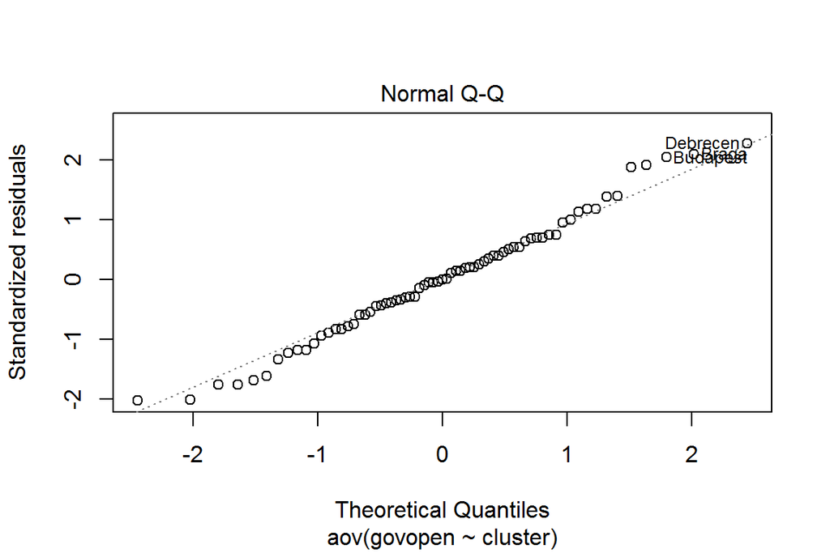

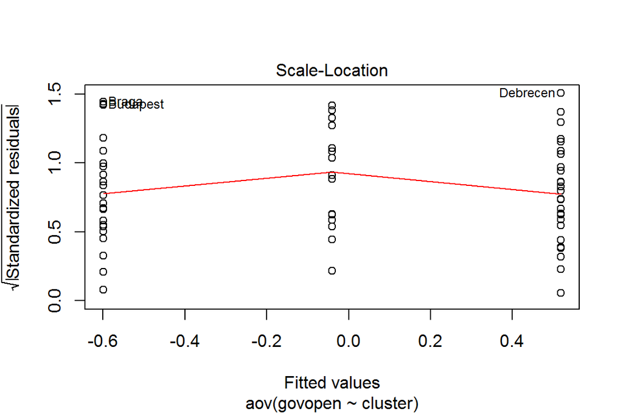

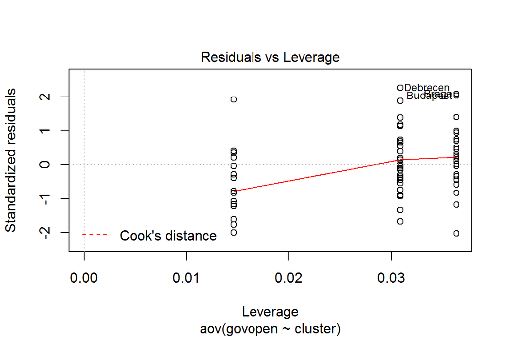

```r
plot(fitgovopen)
```

Normality can be observed from (Normal) QQ-plot. If observations are forming a straight line, then residuals are normally distributed. With *freedom* there is problems, but with *govopen* everything seems to be alright. Homoscedasticity is more problematic espeacilly with *freedom*: residuals have pattern how they are compared to the zero-line. With *govopen* same problems can’t be seen. Because of that I will provide Kruskal-Wallis Test for *freedom*. K-W-test is quite similar to ANOVA, but it uses medians, not means.

```r
kruskal.test(freedom ~ cluster, data=trust_data)
```

```
##
##  Kruskal-Wallis rank sum test
##
## data:  freedom by cluster
## Kruskal-Wallis chi-squared = 53.36, df = 2, p-value = 2.588e-12
```

Fortunately Kruskal-Wallis Test says that there is still statistically significant differences with groups between *freedom*.

# 6 Visualization

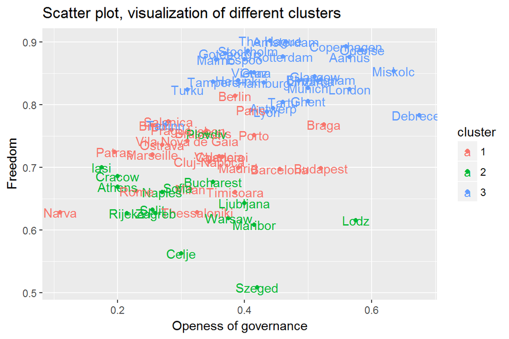

```r
ggplot(data=dist_data, aes(x=govopen, y=freedom, color=cluster, label = rownames(dist_data) )) +
 geom_point() +
 geom_text() +
 labs(x = "Openess of governance", y="Freedom", title="Scatter plot, visualization of different clusters")
```

From the scatterplot can be easily seen differences between clusters. Northern Europe cities (cluster 3) are on top so they get higher scores in *freedom*. Below it is Western Europe cities and on the bottom is Eastern Europe cities. There is some mixing, but the big picture can be seen easily. *govopen* doesn’t make differ so good: it seems that clusters 2 and 1 are quite thoroughly mixed and blue cities are more on the right-hand side. But because there would be 144 different scatter plots to visualize differences, I have provided better tool for that.

# 7 Shiny-app for data visualization

I made a tool for data visualization. It can be found in my shinyapps-repository [here](https://tvkangas.shinyapps.io/trustdata_vis/). With this tool it’s very easy and fast to see how cities are distributed in the scatter plot. For the app, the variables are named better.

## 7.1 Some results

As ANOVA predicted, with variables *houdem* and *busfine* clusters are thoroughly mixed and any pattern can’t be seen. With other variables clustering can be seen more or less clearly. With some variables (e.g. *safe* and *bribe*) only one cluster is separating from two other. Good pairs for to see clustering can be found from correlation plot that is drawn on section Data.

# 8 Conclusions and discussion